# Luftdrucksystemfehler bei Scania Trucks

[figure not shown]

[figure not shown]

[figure not shown]

[figure not shown]

[figure not shown]

[figure not shown]

[figure not shown]

[figure not shown]

[figure not shown]

[figure not shown]

[figure not shown]

# Problematik

### **Problemstellung**

Der Scania-Trucks-Datensatz kommt mit 171 anonymisierten Featuren sowie 76000 Observationen, welche im Verhältnis 60.000 zu 16.000 in Trainings- bzw. Testdaten aufgeteilt sind. Jede Observation enthält die Information, ob ein Fehler im Luftdruckssystem ( im Folgenden **LDS** genannt ) vorliegt oder nicht.  
Die Problemstellung lautet:

*Sage für jede Observation im Testdatensatz voraus, ob ein Fehler im LDS vorliegt oder nicht. Minimiere dabei folgende Kostenfunktion:*  
**$cost(FP, FN) = 10 \cdot FP + 500 \cdot FN$**  
*Es handelt sich hierbei also um ein **Klassifizierungsproblem**, mit der Kostenfunktion $cost(FP, FN)$ als Metrik.*

**Fehler 1. Art (FP):**  
Der Fehler 1. Art, hier **F**alse **P**ositive, bedeutet, dass man einer Observation einen Fehler im LDS zuschreibt, obwohl das Fahrzeug fehlerfrei ist. Man schickt das Fahrzeug also in die Werkstatt, obwohl kein Fehler vorhanden ist.  
**Fehler 2. Art (FN):**  
Der Fehler 2. Art, hier **F**alse **N**egative, bedeutet, dass man eine Observation als fehlerfrei einstuft, obwohl das Fahrezeug einen Fehler im LDS aufweist.

*Der Fehler 1. Art ist deutlich kostengünstiger gewichtet als der Fehler 2. Art. Es ist wesentlich günstiger einen LKW fälschlicherweise in die Werkstatt zur Überprüfung zu schicken, als dass ein LKW, bedingt durch einen **LDS-Fehler**, auf der Strecke liegen bleibt.*

### **Hintergrund**

Das Scania-Trucks-Problem wurde auf der **IDA 2016** vorgestellt. Die IDA ist ein internationales Symposium über intelligente Datenanalyse, welche 2016 im Kontext des **maschinellen Lernens** das Industrieproblem für die Öffentlichkeit zugänglich gemacht hat. Scania, Mitsponsor der IDA, hat auf die beiden kostengünstigsten Modelle einen Preis von 500$ aussgeschrieben, sowie einen Rednerspot auf der **IDA** selbst.

[figure not shown]

# Datensatz

### **Klassenfeature**

Aus der Beschreibung des Scania-Trucks-Problems lässt sich herauslesen, dass gewisse Feature Klassendaten abbilden. Ein Feature ist hierbei auf mehrere Klassen aufgeteilt, wobei der Wert in der Klasse $A_i$ die Aufenthaltsdauer in der Klasse $A_i$ bedeutet. $A$ ist das obergeordnete Feature.  
Beispielverteilung der Feature **ag** & **ay**:

Klassendaten Feature ag

| ag_000 | ag_001 | ag_002 | ag_003 | ag_004 | ag_005 | ag_006 | ag_007 | ag_008 | ag_009 |
| --- | --- | --- | --- | --- | --- | --- | --- | --- | --- |
| 0 | 0 | 0 | 0 | 37250 | 1432864 | 3664156 | 1007684 | 25896 | 0 |
| 0 | 0 | 0 | 0 | 18254 | 653294 | 1720800 | 516724 | 31642 | 0 |
| 0 | 0 | 0 | 0 | 1648 | 370592 | 1883374 | 292936 | 12016 | 0 |
| 0 | 0 | 0 | 318 | 2212 | 3232 | 1872 | 0 | 0 | 0 |
| 0 | 0 | 0 | 0 | 43752 | 1966618 | 1800340 | 131646 | 4588 | 0 |

Klassendaten Feature ay

| ay_000 | ay_001 | ay_002 | ay_003 | ay_004 | ay_005 | ay_006 | ay_007 | ay_008 | ay_009 |
| --- | --- | --- | --- | --- | --- | --- | --- | --- | --- |
| 0 | 0 | 0 | 0 | 0 | 469014 | 4239660 | 703300 | 755876 | 0 |
| 0 | 0 | 0 | 0 | 0 | 71510 | 772720 | 1996924 | 99560 | 0 |
| 0 | 0 | 0 | 0 | 0 | 0 | 870456 | 239798 | 1450312 | 0 |
| 0 | 0 | 0 | 0 | 0 | 0 | 0 | 2038 | 5596 | 0 |
| 0 | 0 | 0 | 0 | 42124 | 372236 | 2128914 | 819596 | 584074 | 0 |

### Feature **ag**

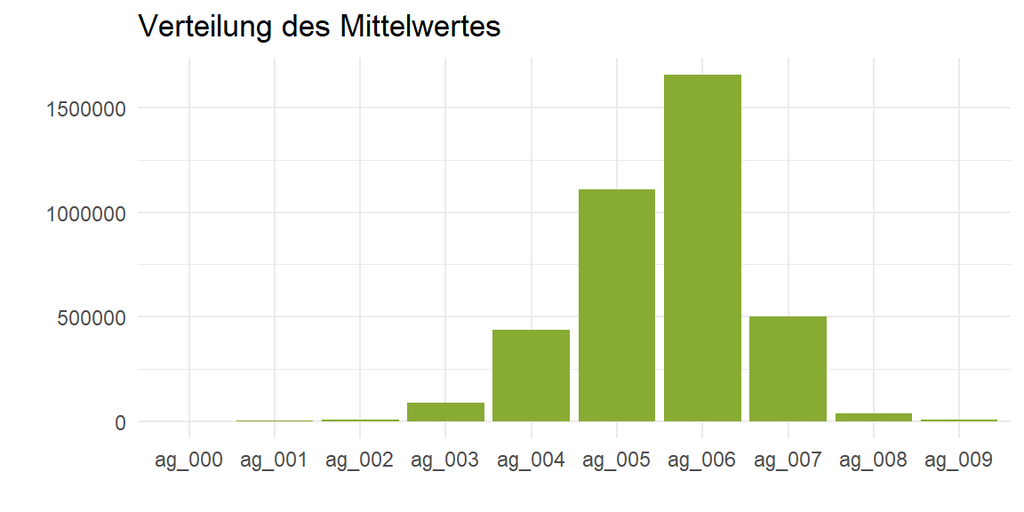

| Var | Min. | 1st Qu. | Median | Mean | 3rd Qu. | Max. | NA’s |
| --- | --- | --- | --- | --- | --- | --- | --- |
| ag_000 | 0 | 0.0 | 0 | 200.43 | 0.0 | 3376892 | 860 |
| ag_001 | 0 | 0.0 | 0 | 1204.76 | 0.0 | 10472522 | 860 |
| ag_002 | 0 | 0.0 | 0 | 9697.33 | 0.0 | 19149160 | 860 |
| ag_003 | 0 | 0.0 | 0 | 93649.02 | 0.0 | 73057472 | 860 |
| ag_004 | 0 | 310.0 | 3682 | 448342.62 | 50226.0 | 228830570 | 860 |
| ag_005 | 0 | 14004.5 | 176963 | 1122573.28 | 916692.5 | 179187978 | 860 |
| ag_006 | 0 | 10872.0 | 937712 | 1666271.73 | 1887378.0 | 94020666 | 860 |
| ag_007 | 0 | 0.0 | 118927 | 500795.41 | 590030.0 | 63346754 | 860 |
| ag_008 | 0 | 0.0 | 1776 | 35643.89 | 26930.0 | 17702522 | 860 |
| ag_009 | 0 | 0.0 | 0 | 5255.75 | 374.0 | 25198514 | 860 |

### Feature **ay**

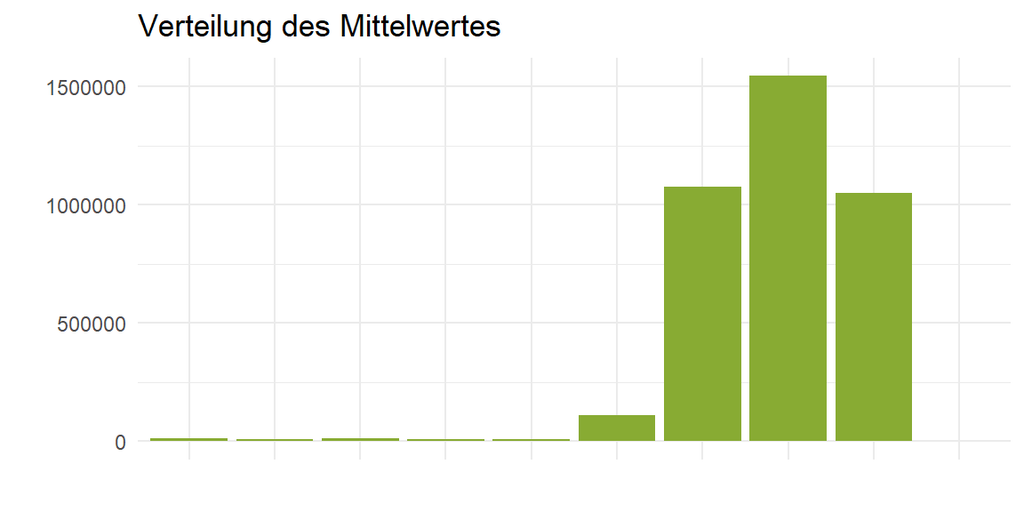

| Var | Min. | 1st Qu. | Median | Mean | 3rd Qu. | Max. | NA’s |
| --- | --- | --- | --- | --- | --- | --- | --- |
| ay_000 | 0 | 0 | 0 | 14956.21 | 0 | 74041092 | 863 |
| ay_001 | 0 | 0 | 0 | 11334.45 | 0 | 80525378 | 863 |
| ay_002 | 0 | 0 | 0 | 11352.12 | 0 | 30231168 | 863 |
| ay_003 | 0 | 0 | 0 | 7321.96 | 0 | 13945170 | 863 |
| ay_004 | 0 | 0 | 0 | 10161.25 | 0 | 40028704 | 863 |
| ay_005 | 0 | 0 | 0 | 106661.34 | 39808 | 124948914 | 863 |
| ay_006 | 0 | 0 | 168202 | 1081914.25 | 1269102 | 127680326 | 863 |
| ay_007 | 0 | 6118 | 351576 | 1556826.89 | 1339224 | 489678156 | 863 |
| ay_008 | 0 | 7636 | 96330 | 1078964.92 | 620060 | 326836844 | 863 |
| ay_009 | 0 | 0 | 0 | 1158.22 | 0 | 18824656 | 863 |

### Feature **az**

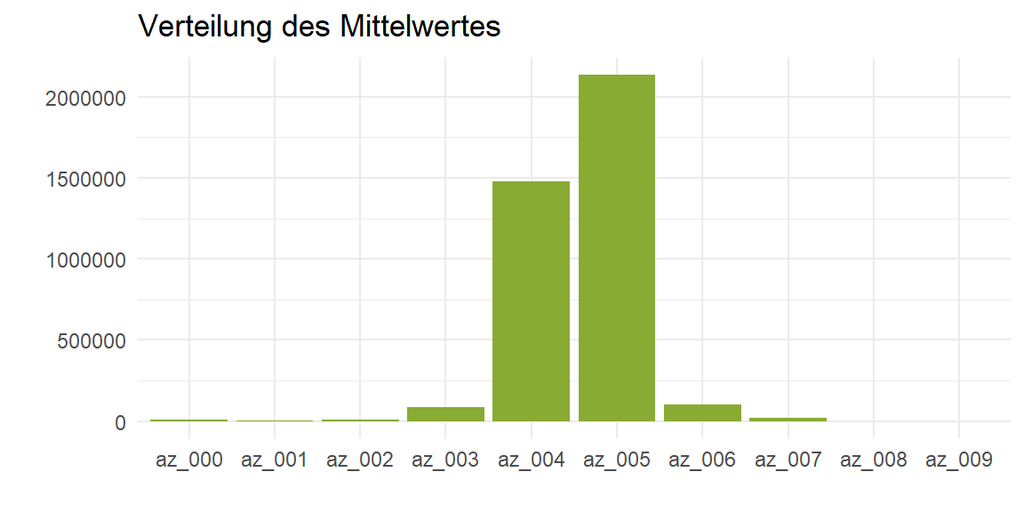

| Var | Min. | 1st Qu. | Median | Mean | 3rd Qu. | Max. | NA’s |
| --- | --- | --- | --- | --- | --- | --- | --- |
| az_000 | 0 | 1032 | 2102 | 7899.45 | 4164 | 10124620 | 863 |
| az_001 | 0 | 60 | 642 | 4486.53 | 2030 | 4530258 | 863 |
| az_002 | 0 | 90 | 1024 | 8046.20 | 3144 | 14217662 | 863 |
| az_003 | 0 | 296 | 3604 | 87721.73 | 43262 | 45584242 | 863 |
| az_004 | 0 | 1544 | 84036 | 1488475.23 | 1777978 | 132037276 | 863 |
| az_005 | 0 | 39066 | 529990 | 2162875.29 | 1795944 | 481046524 | 863 |
| az_006 | 0 | 10 | 296 | 102604.91 | 4284 | 64589140 | 863 |
| az_007 | 0 | 0 | 0 | 17884.03 | 0 | 39158218 | 863 |
| az_008 | 0 | 0 | 0 | 634.16 | 0 | 1947884 | 863 |
| az_009 | 0 | 0 | 0 | 37.61 | 0 | 666148 | 863 |

### Feature **ba**

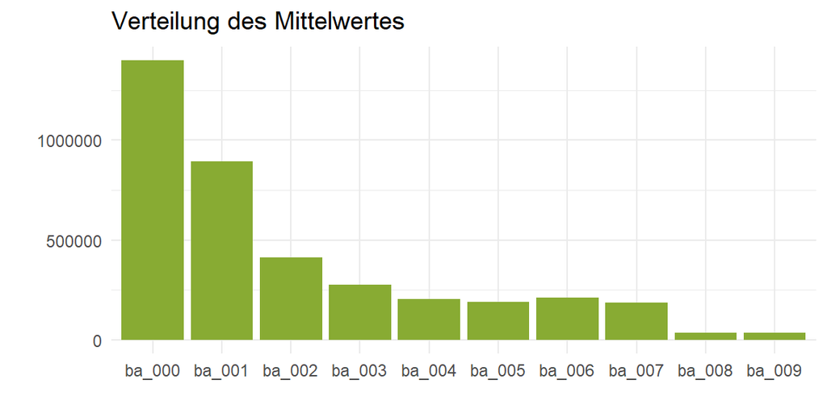

| Var | Min. | 1st Qu. | Median | Mean | 3rd Qu. | Max. | NA’s |
| --- | --- | --- | --- | --- | --- | --- | --- |
| ba_000 | 0 | 33716 | 681582 | 1414577.16 | 1276450 | 232871714 | 881 |
| ba_001 | 0 | 15175 | 445210 | 904111.48 | 813840 | 142000418 | 881 |
| ba_002 | 0 | 5305 | 186752 | 417998.21 | 341039 | 55807388 | 881 |
| ba_003 | 0 | 1882 | 134820 | 277535.98 | 244747 | 36931418 | 881 |
| ba_004 | 0 | 628 | 102432 | 207682.64 | 197352 | 25158556 | 881 |
| ba_005 | 0 | 380 | 84380 | 190997.65 | 184704 | 19240550 | 881 |
| ba_006 | 0 | 356 | 70426 | 211596.66 | 205674 | 18997660 | 881 |
| ba_007 | 0 | 74 | 4670 | 186797.99 | 208142 | 15427264 | 881 |
| ba_008 | 0 | 0 | 22 | 36271.00 | 1840 | 31265984 | 881 |
| ba_009 | 0 | 0 | 0 | 37121.54 | 62 | 43706408 | 881 |

### Feature **cn**

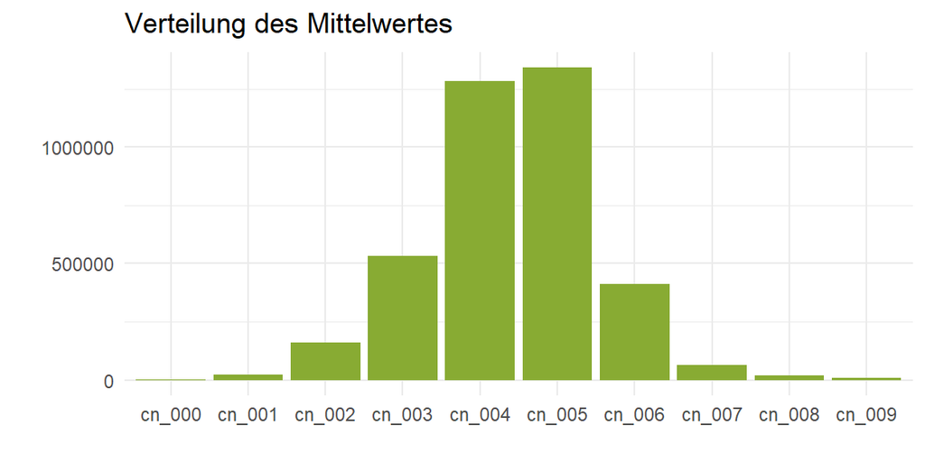

| Var | Min. | 1st Qu. | Median | Mean | 3rd Qu. | Max. | NA’s |
| --- | --- | --- | --- | --- | --- | --- | --- |
| cn_000 | 0 | 0 | 0 | 2678.81 | 0 | 12567090 | 881 |
| cn_001 | 0 | 0 | 0 | 24041.10 | 0 | 45317856 | 881 |
| cn_002 | 0 | 0 | 0 | 166081.35 | 8049 | 83977900 | 881 |
| cn_003 | 0 | 4654 | 34962 | 541879.58 | 235337 | 160348272 | 881 |
| cn_004 | 0 | 19532 | 519680 | 1298715.45 | 1208926 | 169869316 | 881 |
| cn_005 | 0 | 5194 | 703196 | 1348579.66 | 1519190 | 117815764 | 881 |
| cn_006 | 0 | 634 | 97184 | 410362.22 | 449859 | 72080406 | 881 |
| cn_007 | 0 | 64 | 10016 | 64725.84 | 31079 | 33143734 | 881 |
| cn_008 | 0 | 0 | 1858 | 19651.29 | 5288 | 9628690 | 881 |
| cn_009 | 0 | 0 | 26 | 8018.11 | 294 | 36398374 | 881 |

### Feature **cs**

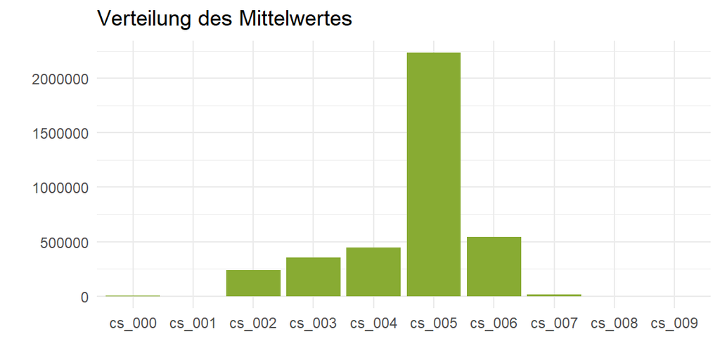

| Var | Min. | 1st Qu. | Median | Mean | 3rd Qu. | Max. | NA’s |
| --- | --- | --- | --- | --- | --- | --- | --- |
| cs_000 | 0 | 1234.0 | 3200 | 5522.76 | 5702.0 | 924996 | 858 |
| cs_001 | 0 | 32.0 | 362 | 792.05 | 694.0 | 438806 | 858 |
| cs_002 | 0 | 232.0 | 20804 | 243057.04 | 94964.0 | 65572940 | 858 |
| cs_003 | 0 | 3138.0 | 122272 | 360247.90 | 296150.0 | 61737200 | 858 |
| cs_004 | 0 | 2772.0 | 91325 | 452960.90 | 209253.5 | 152455352 | 858 |
| cs_005 | 0 | 19493.5 | 1225808 | 2257808.47 | 2051776.5 | 379142116 | 858 |
| cs_006 | 0 | 13482.0 | 241496 | 547189.58 | 687733.0 | 73741974 | 858 |
| cs_007 | 0 | 1208.0 | 6132 | 14724.08 | 18174.0 | 12884218 | 858 |
| cs_008 | 0 | 2.0 | 46 | 247.56 | 148.0 | 2826620 | 858 |
| cs_009 | 0 | 0.0 | 0 | 1024.87 | 0.0 | 44902992 | 858 |

### Feature **ee**

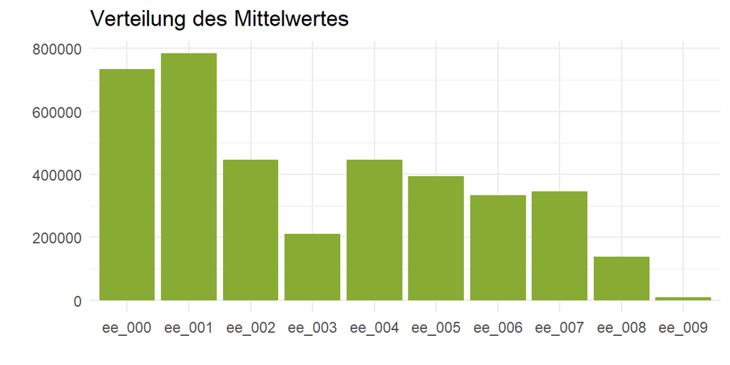

| Var | Min. | 1st Qu. | Median | Mean | 3rd Qu. | Max. | NA’s |
| --- | --- | --- | --- | --- | --- | --- | --- |
| ee_000 | 0 | 15902 | 261804 | 744503.49 | 574486 | 163085734 | 863 |
| ee_001 | 0 | 8620 | 348474 | 788310.87 | 667812 | 98224378 | 863 |
| ee_002 | 0 | 2986 | 235448 | 449576.27 | 438674 | 77933926 | 863 |
| ee_003 | 0 | 1184 | 112672 | 213246.01 | 218410 | 37758390 | 863 |
| ee_004 | 0 | 2730 | 223002 | 450647.79 | 467634 | 97152378 | 863 |
| ee_005 | 0 | 3646 | 190986 | 400620.44 | 403290 | 57435236 | 863 |
| ee_006 | 0 | 530 | 93536 | 337868.93 | 276180 | 42159442 | 863 |
| ee_007 | 0 | 112 | 41260 | 347561.11 | 168046 | 119580108 | 863 |
| ee_008 | 0 | 0 | 3862 | 139896.79 | 139500 | 19267396 | 863 |
| ee_009 | 0 | 0 | 0 | 8424.98 | 2000 | 4570398 | 863 |

# Feature-Engineering

### **NA-Analyse**

Der Scania-Trucks-Datensatz weist eine hohe Zahl an fehlenden Werten ( hier im Folgenden **NA’s** genannt) auf.  
Eine Möglichkeit besteht darin, eine gewisse Anzahl an NA’s zuzulassen und dementsprechend die Anzahl der Feature zu reduzieren. Alle Observationen, welche nach der **Featurereduktion** noch NA’s enthalten, werden entfernt. Unterschieden wird zwischen allen Observationen ( fehlerfrei & fehlerhaft ), und den fehlerhaften Observationen ( Observationen die einen Fehler aufweisen ).  
Die Anzahl der vorhandenen NA’s in jedem der 171 Feature liefert uns die verschiedenen **NA-Grenzen**.  
Folgender Auszug aus der Tabelle liefert einen Überblick über die NA-Grenzen:

NA-Grenzen, Featureanzahl ( Grün ), allgemeiner Observationsverlust ( Orange ) & fehlerhafter Observationsverlust ( Blau )

| na_number | vars | obs | obs_pos | vars_percent | obs_percent | obs_pos_percent |
| --- | --- | --- | --- | --- | --- | --- |
| 0 | 2 | 76000 | 1375 | 1.169591 | 100.00000 | 100.00000 |
| 195 | 3 | 75805 | 1363 | 1.754386 | 99.74342 | 99.12727 |
| 424 | 6 | 75404 | 1360 | 3.508772 | 99.21579 | 98.90909 |
| 580 | 7 | 75101 | 1359 | 4.093567 | 98.81711 | 98.83636 |
| 751 | 11 | 74616 | 1320 | 6.432748 | 98.17895 | 96.00000 |

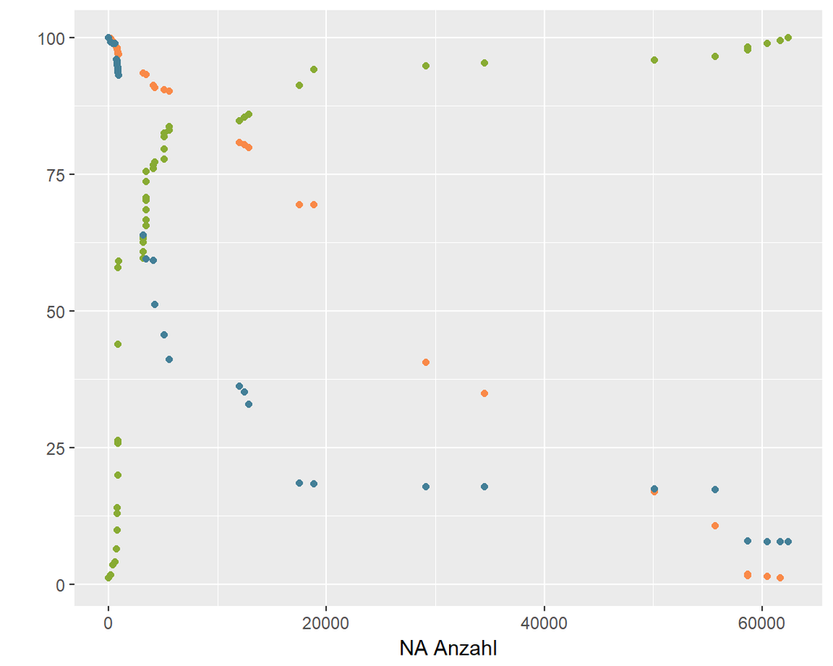

**Featuregewinnung:**

Die Tabelle zeigt, dass bei den unterschiedlichen NA-Grenzen die Anzahl an **gewonnener Feature** stark schwankt. So gewinnt man beim Sprung von 0 auf 195 NA’s lediglich 1 Feature dazu, beim Sprung von 861 auf 863 NA’s aber direkt 30 Feature. Das **NA-Verhalten** ist also alles andere als proportional.  
Die Entscheidung, welche NA-Grenze man als Auschlussverfahren nimmt, hängt aber nicht nur von der Featuregewinnung ab.

**Allgemeiner Observationsverlust:**

Alle Feature im späteren Modell zu berücksichten würde nichts bringen, wenn man nur noch auf 5% der ursprünglichen Daten trainieren kann. Deshalb spielt der **Observationsverlust** eine starke Rolle in der Entscheidung. Hier zeichnet sich ein starker Sprung von 5598 auf 12012 NA’s ab. Evaluiert man also die Grenzen anhand des Observationsverlustes, sollte man nicht über die Grenze von 5598 hinaus gehen, da direkt danach c.a. 10% der betrachteten LKW zusätzlich verloren gehen.

Der Scania-Trucks-Datensatz weist noch ein zusätzliches Problem auf. Von den 76000 Observationen sind lediglich **1375** fehlerhaft. Dadurch könnte es passieren, dass man bei der Wahl der NA-Grenze alle fehlerhaften Observationen verliert.  
Demnach muss zusätzlich folgende Variable mit einkalkuliert werden:

**Fehlerhafter Observationsverlust:**

Der fehlerhafte Oberservationsverlust beschreibt die Anzahl der Observationen, die bei der Wahl der NA-Grenze verloren gehen und zusätzlich einen Fehler im LDS aufweisen. Anhand der geringen Fehlerrate im Datensatz wäre es fatal zu viele der fehlerhaften Fahrzeuge zu verlieren, da ein Modell so möglicherweise auf ausschließlich fehlerfreien Daten trainieren könnte. Die Grenze für fehlerhafte Observationen findet sich in der Tabelle offensichtlich beim Sprung von 928 NA’s auf 3188 NA’s. Obwohl man hier nur 1 Feature dazu gewinnen würde, fallen 30% der fehlerhaften Observationen dadurch raus. Die Grenze ist demnach also bei 928 NA’s zu setzen.

**Fazit:**

Die NA-Analyse zeigt, dass verschiedene Breakpoints existieren, um eine gewisse Anzahl von Featuren zu erhalten / nicht zu viele Observationen zu verlieren. Als ein erster Gedankengang ist diese Art der Analyse nicht schlecht und verschafft einen guten Überblick über den Datensatz. Der individuelle Informationsgehalt der einzelnen Feature wird dabei aber nicht berücksichtigt. Um außerdem auf dem kompletten Trainingsset Vorhersagen treffen zu können, müssen die fehlenden Werte aufgefüllt werden, anstatt **NA-Reduktion** zu betreiben. Hierzu stehen Möglichkeiten wie beispielsweise die **knn-imputation** zur Verfügung. Im Pre-Processing-Tab wird diese Möglichkeit evaluiert.

### **Datenaufbereitung ( Relativierung )**

Die **Datensatzanalyse** hat gezeigt, dass viele der Klassendaten nicht gleichmäßig verteilt sind. Oftmals sind die Klassen eines Klassenfeatures für fast alle Observationen 0. Andere Klassen hingegen sind mit den unterschiedlichsten Größenordnungen von Zahlen gefüllt.  
Hinzu kommt, dass die Werte in den verschiedenen Klassen **absolute** Daten sind:

**$\sum_{i = 0}^{9}{A_i}$**  
ist **nicht notwendigerweise gleich** für alle Observationen.

Um das Problem der absoluten Klassendaten zu beseitigen ist es sinnvoll, diese zu **relativieren**. Man stellt also jeden absoluten Wert in $A_i$ in **prozentuellen Bezug** zu der **Gesamtaufenthaltszeit** der Observation in der Klasse $A$.  
Dadurch ergibt sich folgende Formel für die neuen Werte $\tilde{A}$:

**$\tilde{A}_i = \frac{A_i}{\sum_{i = 0}^{9}{A_i}} mit \sum_{i = 0}^{9}{\tilde{A}_i} = 1$**  
für **jede** Observation.

**Vorher:**

Klassenfeature ag

| ag_000 | ag_001 | ag_002 | ag_003 | ag_004 | ag_005 | ag_006 | ag_007 | ag_008 | ag_009 |
| --- | --- | --- | --- | --- | --- | --- | --- | --- | --- |
| 0 | 0 | 0 | 0 | 37250 | 1432864 | 3664156 | 1007684 | 25896 | 0 |
| 0 | 0 | 0 | 0 | 18254 | 653294 | 1720800 | 516724 | 31642 | 0 |
| 0 | 0 | 0 | 0 | 1648 | 370592 | 1883374 | 292936 | 12016 | 0 |
| 0 | 0 | 0 | 318 | 2212 | 3232 | 1872 | 0 | 0 | 0 |
| 0 | 0 | 0 | 0 | 43752 | 1966618 | 1800340 | 131646 | 4588 | 0 |

**Nachher:**

Klassenfeature ag relativiert

| perc_ag_0 | perc_ag_1 | perc_ag_2 | perc_ag_3 | perc_ag_4 | perc_ag_5 | perc_ag_6 | perc_ag_7 | perc_ag_8 | perc_ag_9 |
| --- | --- | --- | --- | --- | --- | --- | --- | --- | --- |
| 0 | 0 | 0 | 0.0000000 | 0.0060394 | 0.2323117 | 0.5940735 | 0.1633769 | 0.0041985 | 0 |
| 0 | 0 | 0 | 0.0000000 | 0.0062073 | 0.2221549 | 0.5851640 | 0.1757138 | 0.0107600 | 0 |
| 0 | 0 | 0 | 0.0000000 | 0.0006436 | 0.1447305 | 0.7355303 | 0.1144028 | 0.0046927 | 0 |
| 0 | 0 | 0 | 0.0416558 | 0.2897564 | 0.4233691 | 0.2452188 | 0.0000000 | 0.0000000 | 0 |
| 0 | 0 | 0 | 0.0000000 | 0.0110850 | 0.4982635 | 0.4561352 | 0.0333539 | 0.0011624 | 0 |

### **Pre-Processing**

Zusätzlich zu seinen Klassendaten verfügt der Datensatz, wie bereits erwähnt, über eine Vielzahl von **NA’s** ( fehlende Werte ).  
Eine Möglichkeit, diese aufzufüllen, bietet hier die **knn-Imputation** ( *k-nearest-neighbours-Schätzung* ).  
Die Schätzung erfolgt in **3** Schritten.

Zentrieren, Skalieren & Schätzen

Folgende Tabellenausschnitte verdeutlichen diese Schritte:

| 280 |
| --- |
| NA |
| 100 |
| 66 |
| 458 |

| -150350 |
| --- |
| NA |
| -150530 |
| -150564 |
| -150172 |

| -0.0041873 |
| --- |
| NA |
| -0.0041923 |
| -0.0041933 |
| -0.0041824 |

| -0.0041873 |
| --- |
| -0.0041806 |
| -0.0041923 |
| -0.0041933 |
| -0.0041824 |

# Modellierung

### **Modellauswahl & Güte**

Zur Lösung des **Klassifizierungsproblems** wird ein **Random-Forest-Modell** verwendet. Als **Parameterraster** wird $mtry = 13$ und $splitrule =$ *gini-Index* verwendet.  
Der Standardwert von $mtry = \sqrt{Anzahl \space der\space Feature}$ hat sich im Vergleich mit verschiedenen Werten durchgesetzt. Der *gini-Index* wurde jeweils vom Modell als beste *splitrule* gewählt.

**Modell 1: 10-fache, 5-faltige Kreuzvalidierung mit 500 Bäumen**

```
Confusion Matrix and Statistics

          Reference
Prediction   neg   pos
       neg 15182    11
       pos   443   364

               Accuracy : 0.9716
                 95% CI : (0.9689, 0.9741)
    No Information Rate : 0.9766
    P-Value [Acc > NIR] : 1

                  Kappa : 0.6032
 Mcnemar's Test P-Value : <0.0000000000000002

            Sensitivity : 0.9716
            Specificity : 0.9707
         Pos Pred Value : 0.9993
         Neg Pred Value : 0.4511
             Prevalence : 0.9766
         Detection Rate : 0.9489
   Detection Prevalence : 0.9496
      Balanced Accuracy : 0.9712

       'Positive' Class : neg
```

```
Random Forest

60000 samples
  170 predictor
    2 classes: 'neg', 'pos'

No pre-processing
Resampling: Cross-Validated (5 fold, repeated 10 times)
Summary of sample sizes: 48000, 48000, 48000, 48000, 48000, 48000, ...
Resampling results:

  logLoss
  0.02716248

Tuning parameter 'mtry' was held constant at a value of 13

Tuning parameter 'splitrule' was held constant at a value of gini

Tuning parameter 'min.node.size' was held constant at a value of 1
```

*Ergebnis:*  
**Kosten:** 9930  
**Kosten pro LKW:** 0.620625

**Modell 2: 10-fache, 5-faltige Kreuzvalidierung mit 1000 Bäumen**

```
Confusion Matrix and Statistics

          Reference
Prediction   neg   pos
       neg 14995     6
       pos   630   369

               Accuracy : 0.9602
                 95% CI : (0.9571, 0.9632)
    No Information Rate : 0.9766
    P-Value [Acc > NIR] : 1

                  Kappa : 0.5208
 Mcnemar's Test P-Value : <0.0000000000000002

            Sensitivity : 0.9597
            Specificity : 0.9840
         Pos Pred Value : 0.9996
         Neg Pred Value : 0.3694
             Prevalence : 0.9766
         Detection Rate : 0.9372
   Detection Prevalence : 0.9376
      Balanced Accuracy : 0.9718

       'Positive' Class : neg
```

```
Random Forest

60000 samples
  170 predictor
    2 classes: 'neg', 'pos'

No pre-processing
Resampling: Cross-Validated (5 fold, repeated 10 times)
Summary of sample sizes: 48000, 48000, 48000, 48000, 48000, 48000, ...
Resampling results:

  logLoss
  0.02636166

Tuning parameter 'mtry' was held constant at a value of 13

Tuning parameter 'splitrule' was held constant at a value of gini

Tuning parameter 'min.node.size' was held constant at a value of 1
```

*Ergebnis:*  
**Kosten:** 9300  
**Kosten pro LKW:** 0.58125

**Modell 3: 10-fache, 5-faltige Kreuzvalidierung mit 2500 Bäumen**

```
Confusion Matrix and Statistics

          Reference
Prediction   neg   pos
       neg 15158     9
       pos   467   366

               Accuracy : 0.9702
                 95% CI : (0.9675, 0.9728)
    No Information Rate : 0.9766
    P-Value [Acc > NIR] : 1

                  Kappa : 0.5928
 Mcnemar's Test P-Value : <0.0000000000000002

            Sensitivity : 0.9701
            Specificity : 0.9760
         Pos Pred Value : 0.9994
         Neg Pred Value : 0.4394
             Prevalence : 0.9766
         Detection Rate : 0.9474
   Detection Prevalence : 0.9479
      Balanced Accuracy : 0.9731

       'Positive' Class : neg
```

```
Random Forest

60000 samples
  170 predictor
    2 classes: 'neg', 'pos'

No pre-processing
Resampling: Cross-Validated (5 fold, repeated 10 times)
Summary of sample sizes: 48000, 48000, 48000, 48000, 48000, 48000, ...
Resampling results:

  logLoss
  0.02636166

Tuning parameter 'mtry' was held constant at a value of 13

Tuning parameter 'splitrule' was held constant at a value of gini

Tuning parameter 'min.node.size' was held constant at a value of 1
```

*Ergebnis:*  
**Kosten:** 9170  
**Kosten pro LKW:** 0.573125

### **Variablenwichtigkeit**

**Modell 1:**

| Variable | Importance |
| --- | --- |
| bj_000 | 100.00000 |
| aq_000 | 78.81031 |
| ci_000 | 74.10737 |
| cq_000 | 68.37546 |
| ck_000 | 68.04996 |

**Modell 2:**

| Variable | Importance |
| --- | --- |
| bj_000 | 100.00000 |
| aq_000 | 81.60939 |
| ci_000 | 70.18449 |
| am_0 | 70.05829 |
| dn_000 | 69.43048 |

**Modell 3:**

| Variable | Importance |
| --- | --- |
| bj_000 | 100.00000 |
| aq_000 | 79.34041 |
| ci_000 | 71.16421 |
| am_0 | 67.81392 |
| perc_ag_2 | 64.39035 |

### **Laufzeit**

**Specs:**

*Intel(R) Core(TM) i5-6200U CPU @ 2.30GHz, 2400 MHz, 2 Kerne, 4 logische Prozessoren, 8GB RAM*  
*Gerechnet wurde auf 3 Prozessoren*

**Modell 1:**

**$Laufzeit \approx 1 \space Stunde \space 11 \space Minuten$**

**Modell 2:**

**$Laufzeit \approx 2 \space Stunden \space 21 \space Minuten$**

**Modell 3:**

**$Laufzeit \approx 5 \space Stunden \space 57 \space Minuten$**

# Klassifizierung

Um die verursachten Kosten der Modelle ( Modellierungs-Tab ) ausrechnen zu können, muss nach der Vorhersage der Wahrscheinlichkeiten noch klassifiziert werden. Hierfür muss ein *threshold* gewählt werden, nachdem eine Observation entweder der fehlerhaften oder der fehlerfreien Klasse zugeordnet wird.  
Dies geschieht in 3 Schritten:  
1.) Berechne die Kosten für die *thresholds* im Intervall $[0,1]$ mit Schrittweite $\frac{1}{100}$  
Wiederhole:  
2.) Plotte die Kostenfunktion und ermittle einen Bereich, in dem das Minimum vorliegt  
3.) Wähle das Intervall $[a,b]$ in dem das Minimum vorliegt, um dieses genauer einschränken zu können

### **Modell 1 ( 10-fache, 5-faltige Kreuzvalidierung mit 500 Bäumen )**

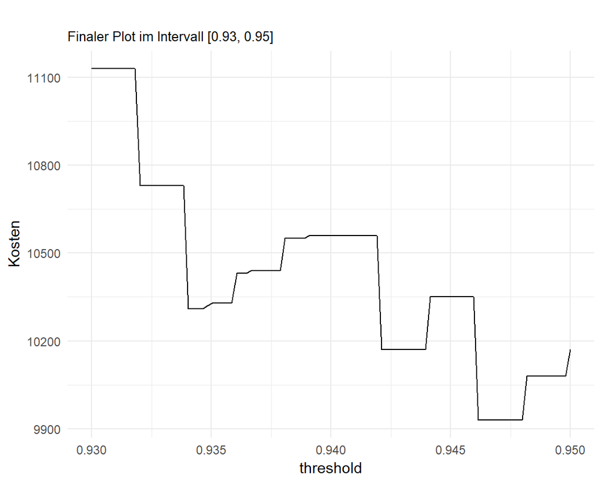

**Optimaler threshold:**  
*0.9461616*

*Ist der Algorithmus sich zu $\approx$ 94.62% sicher, dass eine Observation fehlerfrei ist, klassifiziere diese als fehlerfrei. Andernfalls klassifiziere sie als fehlerhaft.*

### **Modell 2 ( 10-fache, 5-faltige Kreuzvalidierung mit 1000 Bäumen )**

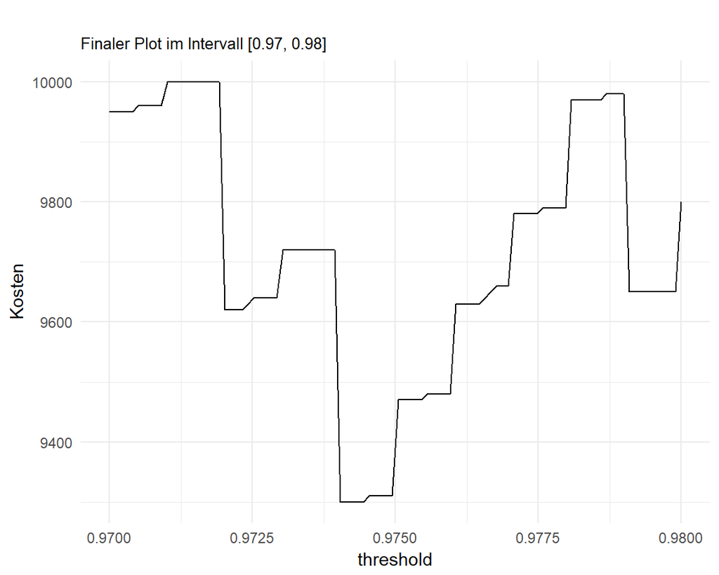

**Optimaler threshold:**  
*0.9740404*

*Ist der Algorithmus sich zu $\approx$ 97.4% sicher, dass eine Observation fehlerfrei ist, klassifiziere diese als fehlerfrei. Andernfalls klassifiziere sie als fehlerhaft.*

### **Modell 3 ( 10-fache, 5-faltige Kreuzvalidierung mit 2500 Bäumen )**

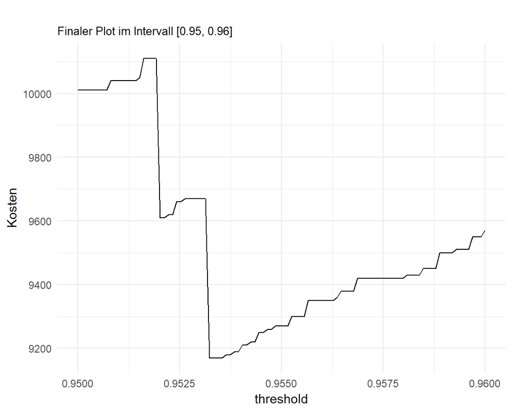

**Optimaler threshold:**  
*0.9532323*

*Ist der Algorithmus sich zu $\approx$ 95.32% sicher, dass eine Observation fehlerfrei ist, klassifiziere diese als fehlerfrei. Andernfalls klassifiziere sie als fehlerhaft.*

# Kostenvergleich

Um die Kostenersparnis unseres “Siegermodells” festzustellen, benötigen wir Vergleichswerte. Nehmen wir im Folgenden an, es existieren keine datenanalytischen Methoden, um dem Luftdruckssystemfehler in gewisser Weise vorzubeugen. Wie würde man vorgehen?

### **Guessing at Random**

Eine Möglichkeit bietet sich darin, einfach zu raten. Sicherlich ist diese Methode nicht besonders effektiv, aber vielleicht lassen sich so ein paar der betroffenen LKW vorsorglich in die Werkstatt schicken.

```
Confusion Matrix and Statistics

          Reference
Prediction  neg  pos
       neg 7855  187
       pos 7770  188

               Accuracy : 0.5027
                 95% CI : (0.4949, 0.5105)
    No Information Rate : 0.9766
    P-Value [Acc > NIR] : 1

                  Kappa : 0.0004
 Mcnemar's Test P-Value : <0.0000000000000002

            Sensitivity : 0.50272
            Specificity : 0.50133
         Pos Pred Value : 0.97675
         Neg Pred Value : 0.02362
             Prevalence : 0.97656
         Detection Rate : 0.49094
   Detection Prevalence : 0.50262
      Balanced Accuracy : 0.50203

       'Positive' Class : neg
```

**Kosten:** 171200  
**Kosten pro LKW:** 10.7

### **Das wird schon**

Eine weitere Möglichkeit wäre, auf sein Glück zu vertrauen und keinen LKW in die Werkstatt zu schicken - “das wird schon”. Auch wenn das sehr riskant ist, sind, wie bereits in der Datensatzanalyse gezeigt, nur wenige der LKW überhaupt betroffen.

```
Confusion Matrix and Statistics

          Reference
Prediction   neg   pos
       neg 15625   375
       pos     0     0

               Accuracy : 0.9766
                 95% CI : (0.9741, 0.9789)
    No Information Rate : 0.9766
    P-Value [Acc > NIR] : 0.5137

                  Kappa : 0
 Mcnemar's Test P-Value : <0.0000000000000002

            Sensitivity : 1.0000
            Specificity : 0.0000
         Pos Pred Value : 0.9766
         Neg Pred Value :    NaN
             Prevalence : 0.9766
         Detection Rate : 0.9766
   Detection Prevalence : 1.0000
      Balanced Accuracy : 0.5000

       'Positive' Class : neg
```

**Kosten:** 187500  
**Kosten pro LKW:** 11.71875

### **Sicher ist sicher**

Eine letzte Möglichkeit liefert die “Sicherheitsvariante”. Wenn man jeden LKW in die Werkstatt schickt, kann zumindest kein Fehler übersehen werden. Aber auch das bringt natürlich gewisse Kosten mit sich.

```
Confusion Matrix and Statistics

          Reference
Prediction   neg   pos
       neg     0     0
       pos 15625   375

               Accuracy : 0.0234
                 95% CI : (0.0211, 0.0259)
    No Information Rate : 0.9766
    P-Value [Acc > NIR] : 1

                  Kappa : 0
 Mcnemar's Test P-Value : <0.0000000000000002

            Sensitivity : 0.00000
            Specificity : 1.00000
         Pos Pred Value :     NaN
         Neg Pred Value : 0.02344
             Prevalence : 0.97656
         Detection Rate : 0.00000
   Detection Prevalence : 0.00000
      Balanced Accuracy : 0.50000

       'Positive' Class : neg
```

**Kosten:** 156250  
**Kosten pro LKW:** 9.765625

### **Fazit**

Natürlich gäbe es noch mehr Möglichkeiten. Beispielsweise, in dem man eine Stichprobe der Größe *n* in die Werkstatt schickt und den Rest so fahren lässt. Es zeigt sich aber doch sehr deutlich, wie kostenintensiv solche Problematiken ohne Datenanalytik werden können.  
Vertraut Scania auf die getroffenen Vorhersagen, so entstehen Gesamtkosten von ca. 9170. Schickt die Firma alle LKW in die Werkstatt, entstehen schnell Kosten von über 156000.  
Der Aspekt *Predictive Maintenance* zur Kostenminimierung ist also ein essenzieller Bestandteil moderner Unternehmen und aus dem Handwerkskasten der Statistiker und Analytiker nicht mehr wegzudenken.

# Über eoda

Über die eoda GmbH:  
eoda ist ein auf Data Science spezialisiertes IT-Unternehmen. Das Portfolio umfasst Consulting, Analytic Services, Software und Training. Die Leistungen erstrecken sich dabei über den gesamten Workflow vom Datenmanagement über die Analyse und Interpretation der Ergebnisse bis hin zur Integration von Analyse-Workflows in bestehende Prozesse und Applikationen. Das interdisziplinäre Team von eoda kombiniert fundiertes Wissen über Geschäftsprozesse mit der kompetenten Anwendung der passenden statistischen Analyseverfahren.

Als Pionier in Deutschland für die Open Source Programmiersprache R bietet eoda ein umfassendes Portfolio für den produktiven Einsatz von R. Spark, AI-Frameworks wie tensorflow oder MxNet und andere Data-Science-Sprachen wie Python und Julia vervollständigen unser Toolkit und helfen uns, die täglichen Herausforderungen von Data Science zu meistern.

eoda bietet ein ganzheitliches Trainings- und Qualifizierungskonzept für R und Python. Wir bieten Schulungen in deutscher und englischer Sprache an.

Für weitere Informationen, kontaktieren Sie uns über:

www.eoda.de

About eoda GmbH:  
eoda is an IT company specialized in data science. Its portfolio comprises consulting, analytic services, software and training. The services cover the entire workflow from data acquisition to analysis to the interpretation of results and the integration of analysis workflows into existing processes and applications. The interdisciplinary team of eoda combines a profound knowledge of business processes with a competent usage of suitable methods for statistical analysis.

As a pioneer in Germany for the open source statistical language R, eoda provides a comprehensive portfolio for the productive application of R. The use of spark, AI frameworks like tensorflow or MxNet and other data science languages like Python and Julia complete our toolkit and help us master the daily challenges of data science.

eoda provides a unique holistic training and qualification concept for R and Python. We can provide trainings in both German and English.

For further information, contact us on:

www.eoda.de

[figure not shown]